*Epilepsia.* 2022;63:1607–1618.

| <sup>**1607**</sup>

wileyonlinelibrary.com/journal/epi

Received: 21 December 2021 | Revised: 19 April 2022 | Accepted: 19 April 2022

DOI: 10.1111/epi.17266

**C R I T I C A L R E V I E W – I N V I T E D C O M M E N TA RY**

**Mesenchymal stem cell therapy for focal epilepsy:**

**A systematic review of preclinical models and clinical studies**

**Andres Ramos- Fresnedo**<sup>**1**</sup> | **Carlos Perez- Vega**<sup>**1**</sup> | **Ricardo A. Domingo**<sup>**1**</sup> |

**Seung Jin Lee**<sup>**1**</sup> | **Ralph B. Perkerson**<sup>**2**</sup> | **Abba C. Zubair**<sup>**3**</sup> | **Kanekiyo Takahisa**<sup>**2**</sup> |

**William Tatum**<sup>**4**</sup> | **Alfredo Quinones- Hinojosa**<sup>**1**</sup> | **Erik. H. Middlebrooks**<sup>**5**</sup> |

**Sanjeet S. Grewal**<sup>**1**</sup>

© 2022 International League Against Epilepsy

1Department of Neurologic Surgery,

Mayo Clinic, Jacksonville, Florida, USA

2Department of Neuroscience and

Center for Regenerative Medicine,

Mayo Clinic, Jacksonville, Florida, USA

3Laboratory Medicine and Pathology

and Center for Regenerative Medicine,

Mayo Clinic, Jacksonville, Florida, USA

4Department of Neurology, Mayo

Clinic, Jacksonville, Florida, USA

5Division of Neuroradiology,

Department of Radiology, Mayo Clinic,

Jacksonville, Florida, USA

**Correspondence**

Sanjeet S. Grewal, Division of

Functional Neurosurgery, Department

of Neurologic Surgery, Mayo Clinic,

4500 San Pablo Rd. S, Jacksonville, FL

32224, USA.

Email: grewal.sanjeet@mayo.edu

**Funding information**

Florida State Department of Health

Research; Mayo Clinic Graduate

School; NIH, Grant/Award Number:

R43CA221490, R01CA200399,

R01CA195503 and R01CA216855;

Boston Scientific Corp.; Varian Medical

Systems, Inc

**Abstract**

Drug- resistant epilepsy (DRE) is characterized by recurrent seizures despite ap-

propriate treatment with antiseizure medication (ASM). Due to their regenerative

and immunomodulatory potential, therapies with biologics such as mesenchy-

mal stem cells (MSCs) offer a potential therapeutic benefit for structural causes

of epilepsy, such as hippocampal sclerosis. In this article, we report a systematic

review of the literature evaluating the preclinical and clinical studies of MSCs

for DRE. Medline, Ovid EMBASE, Scopus, and the Cochrane Databases were

searched electronically from their dates of inception to November 2021 using the

following keywords: ((“mesenchymal”) AND (“stem cell”)) AND ((“epilepsy”)

OR (“convulsion”) OR (“seizures”)). This review followed Preferred Reporting

Items for Systemic Reviews and Meta- Analyses (PRISMA) guidelines. The initial

query identified 488 studies representing 323 unique manuscripts. After appli-

cation of selection criteria, 15 studies were included in this systematic review;

11 were preclinical studies and 4 were clinical studies. All preclinical studies

were performed in rodents and all clinical studies were phase 1 trials. Thus far,

therapy with MSCs appears to be safe for use in humans, as no severe adverse

events related directly to the therapy were reported. Furthermore, MSC therapy

appears to provide a statistically significant clinical benefit by reducing the sei-

zure burden of patients, reducing the electrophysiological biomarkers of epilepsy,

and improving their comorbidities, such as depression and anxiety. In addition,

animal studies reveal that the therapy exerts its effect by reducing aberrant mossy

fiber sprouting (reduce excitatory pathways) and increasing γ- aminobutyric acid

(GABA)ergic interneurons (increase inhibitory pathways). Both preclinical and

clinical studies have shown MSC therapy to be safe and preliminary effective,

thus warranting further studies to investigate its therapeutic potential.

**K E Y W O R D S**

animal model, biologics, clinical trial, human study, mesenchymal stem cells

**1608** **|**

RAMOS- FRESNEDO et al.

**1** | **INTRODUCTION**

The International League Against Epilepsy (ILAE) task

force defines epilepsy as a disease of the brain character-

ized by any of the following: (1) at least two unprovoked

(or reflex) seizures occurring >24 h apart; (2) one un-

provoked (or reflex) seizure and at least a 60% probabil-

ity of further seizures, similar to the general recurrence

risk after two unprovoked seizures; (3) diagnosis of an

epilepsy syndrome.<sup>1</sup> The most common structural finding

of temporal lobe epilepsy (TLE) in adults is hippocampal

sclerosis.<sup>2</sup> This abnormality is the result of degeneration

of γ- aminobutyric acid (GABA)ergic interneurons in this

area. Normally these neurons secrete inhibitory neuro-

transmitters to stop the propagation of abnormal epilepti-

form activity resulting in a seizure.<sup>3– 5</sup>

The mainstay of treatment for epilepsy is seizure con-

trol with antiseizure medication (ASM).<sup>6– 8</sup> When two

adequate trials of ASM fail to achieve sustained seizure

freedom and both are well tolerated and appropriately

chosen for an individual epilepsy syndrome, the disorder

is referred to as drug- resistant epilepsy (DRE).<sup>9</sup> Patients

with DRE with a seizure focus that can be localized to a

specific area of the brain may be candidates for epilepsy

surgery. The latter situation provides a window of oppor-

tunity for local delivery of alternative therapies.<sup>10,11</sup>

Recently, due to their regenerative potential, mes-

enchymal stem cells (MSCs) have arisen as a promising

alternative to reinvigorate damaged tissue in multiple dis-

eases, including epilepsy.<sup>12– 20</sup> It is thought that these cells

are able to repopulate and differentiate into the lost hippo-

campal interneurons of patients with hippocampal scle-

rosis and DRE, thus improving seizure outcome.<sup>21– 23</sup> We

systematically review the current literature for scientific

documents involving preclinical models and human stud-

ies of MSC therapy for epilepsy.

**2** | **METHODS**

**2.1** | **Search strategy**

Our literature search strategy was framed using the

Population, Intervention, Comparison, Outcome, and

Study type (PICOS) model to develop relevant clinical

questions formatted for systematic review.<sup>24</sup> These ques-

tions were: Do subjects with DRE (population) treated

with MSCs either locally or systemically (intervention)

show clinical and electroencephalographical improve-

ment (outcomes) vs subjects treated with the current

standard ASM (comparison) based on current preclini-

cal and clinical studies of MSC therapy for epilepsy

(study type). Medline, Ovid EMBASE, Scopus, and the

Cochrane Databases were electronically searched from

their dates of inception to November 2021. The following

keywords were typed in the search box as stated: ((“mes-

enchymal”) AND (“stem cell”)) AND ((“epilepsy”) OR

(“convulsion”) OR (“seizures”)). Our review followed the

Preferred Reporting Items for Systematic Reviews and

Meta- Analyses (PRISMA) guidelines.<sup>25</sup> We confirm that

we have read the Journal's position on issues involved in

ethical publication and affirm that this report is consistent

with those guidelines.

**2.2** | **Study selection**

In accordance with the PRISMA guidelines, scientific

publications were independently screened by two au-

thors (A.R.F. and C.P.V.) through Endnote software for

Mac (Version 9; Clarivate). No discrepancies between the

screening authors were found. Duplicate records were au-

tomatically removed by the software and the remaining

duplicate records were manually removed by the screen-

ing authors. All studies with at least one outcome of in-

terest that included animal models of epilepsy or human

subjects were screened when subjects received at least

one application (either local or systemic) of naïve or engi-

neered MSCs. Studies that used other types of stem cells or

precursor cells, such as neural- induced pluripotent stem

cells, were excluded. Abstracts, book chapters, and manu-

scripts not written in English were excluded. For dupli-

cate studies with overlapping cohorts, the most complete

report was included.

**2.3** | **Data collection and analysis**

For preclinical studies, the animal strain, number of ani-

mals, model used, therapy used, MSC source of stem cells,

**Key points**

• Mesenchymal stem cell (MSC) therapy in early

treatment for drug- resistant epilepsy (DRE).

• Preliminary human studies on MSC therapy for

DRE have suggested a clinical benefit on sei-

zure control.

• Preliminary human studies on MSC therapy for

DRE have suggested a clinical benefit on co-

morbidities (depression/anxiety).

• Further phase 2 clinical studies are warranted

to explore this therapy.

**|** **1609**

RAMOS- FRESNEDO et al.

dosage, timing of delivery, method of delivery, and main

findings were extracted from full texts, tables, and fig-

ures. For clinical studies, the number of subjects, study

design, MSC source, dosage, timing of delivery, method

of delivery, study endpoints, and main findings were ex-

tracted from full texts and tables. Due to the nature and

heterogeneity of the data, a quantitative meta- analysis

was not conducted; hence a quality assessment was not

performed. Descriptive statistics were used to report the

search results.

**3** | **RESULTS**

**3.1** | **Search strategy**

Our initial search (Figure 1) identified 488 manuscripts

representing 323 unique scientific reports. After applica-

tion of selection criteria to the title and abstract, 18 pub-

lications were selected for full- text analysis. Of the 18

publications, 15 met the inclusion criteria and were in-

cluded in this article.<sup>21– 23,26– 37</sup> From the included 15 pub-

lications, 11 were preclinical models (Table 1) and 4 were

clinical studies (one case report and three phase 1 clinical

trials; Table 2).

**3.2** | **Preclinical study characteristics**

All preclinical models (Table 1) were performed in rodents

animals (33.41%) received treatment with naïve MSCs, 81

(19.47%) with engineered MSCs, 113 (27.16%) received

sham treatment, 75 (18.03%) served as controls, and 8

(1.92%) received treatment with ASM only. The mod-

els used included five (45.45%) intraperitoneal lithium-

pilocarpine- induced status epilepticus (SE), two (18.18%)

intraperitoneal pilocarpine- induced SE, three (27.27%) in-

trahippocampal kainic acid- induced SE, and one (9.09%)

intraperitoneal pentylenetetrazole- induced chronic epi-

lepsy model. From the 11 models; 6 (54.55%) used animal

bone marrow- derived MSCs; whereas the remaining 5

(45.45%) used human- derived MSCs from bone marrow

(*n* = 2), umbilical cord blood (*n* = 2), and a Wharton's jelly

isolate (*n* = 1).

Cell dosage varied by method of delivery. From the

11 studies, 7 used stereotactic intrahippocampal injec-

of 5 000 000 cells, and 3 used a systemic injection through

a tail vein at a dose ranging from 1 000 000 to 3 000 000

**3.3** | **Clinical study characteristics**

From the four included studies (Table 2), three were phase

1/pilot studies in adults with DRE and one was a pediat-

ric case report. All three phase 1/pilot studies were open

label and two of them were randomized. All studies had at

least 1 year of follow- up; had a primary end point of safety,

feasibility, and tolerability; and a secondary end point of

efficacy and seizure burden reduction.

All four studies enrolled a total of 94 patients— 89

(94.68%) were adults and 5 (5.32%) were pediatric— and

**FIGURE 1**

Preferred Reporting

Items for Systemic Reviews and Meta-

Analyses (PRISMA) flow chart illustrating

the selection of articles included in this

review

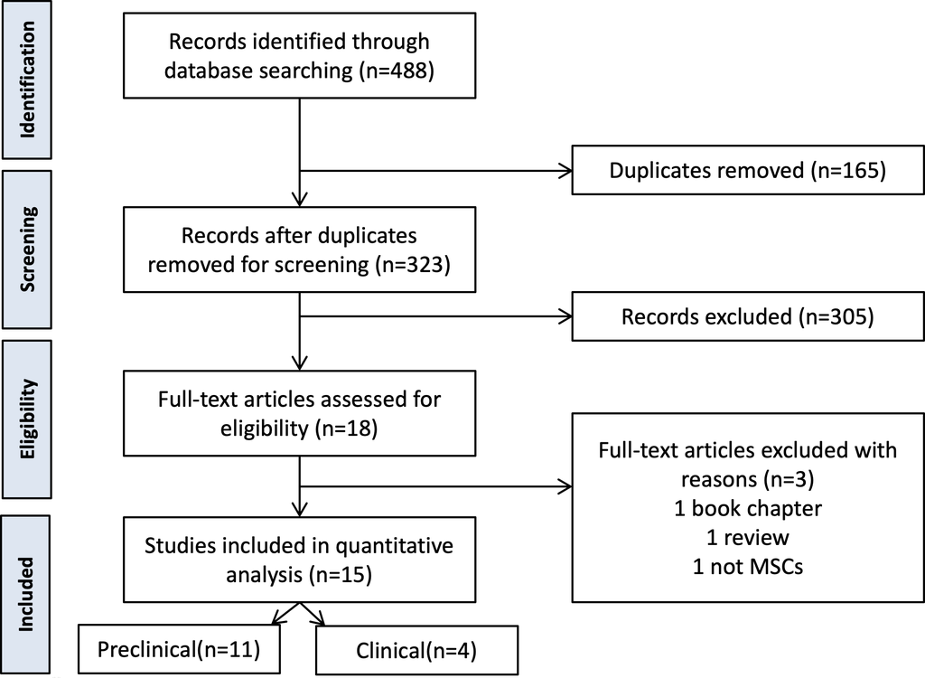

**1610** **|**

RAMOS- FRESNEDO et al.

**TABLE 1** Preclinical studies of MSC therapy for epilepsy

**Author (year)**

**Study subjects (Total,**

**group allocation)**

**Number of subjects**

**per treatment**

**group**

**Model and therapeutics**

**MSC source, dose, timing,**

**and method of delivery**

**Main histopathological**

**findings**

**Main clinical**

**findings**

Fukumura et al.

(2018)21

Male Sprague- Dawley

rats

29 total

10 naïve MSCs

11 sham

8 controls

Intraperitoneal lithium-

pilocarpine– induced SE

Naïve cells

Rat bone marrow, 1 × 106

cells, tail vein injection,

1 day after SE induction

MSCs reduceda aberrant mossy

fiber sprouting in the

dentate gyrus vs sham

MSCs increaseda the number

of hippocampal GABAergic

neurons (vs sham) to an

amount similar to controls

MSCs decreaseda

seizure

frequency

and improved

cognitive

function vs.

sham.

Huang et al.

(2016)23

Male Sprague- Dawley

rats

60 total

20 naïve MSCs

20 sham

20 controls

Intraperitoneal

pilocarpine- induced SE

Naïve cells

Human Wharton's jelly,

1 × 105 cells, bilateral

intrahippocampal

injection, 1 day after SE

induction

MSCs reduceda brain edema

and aberrant mossy

fiber sprouting in the

hippocampus vs sham

Hippocampal volume and

hippocampal neuron

density were similar

between the MSCs and

control groups but greatera

vs sham

MSCs reduceda

the frecuency

and duration

of seizures vs.

sham.

Kang et al.

(2012)27

Wistar rats

16 total

8 naïve MSCs

8 sham

Intraperitoneal lithium-

pilocarpine– induced SE

Naïve cells

Rat bone marrow,

4 × 103 cells, right

intrahippocampal

injection, 30 days after SE

induction

MSCs increaseda adenosine A1

receptor in the temporal

lobe and hippocampus and

decreaseda adenosine A2a

receptor in the thalamus

vs sham

MSCs reduceda

the frequency

and amplitude

of epileptic

discharges vs.

sham.

Long et al. (2015)29

Male Sprague- Dawley

rats

45 total

15 naïve MSCs

15 labeled MSCs

15 sham

Intraperitoneal lithium-

pilocarpine– induced SE

Naïve cells or Ultrasmall

superparamagnetic iron

oxide nanoparticles

(USPIO)- labeled cells

Rat bone marrow, 5 × 106

cells, unilateral

intraventricular injection,

2 h after SE induction

Labeled MSCs migrated

toward the cortex and the

hippocampus

Naïve and labelled

MSCs reduceda

the frequency

of seizures vs.

sham.

Long et al. (2013)30

Male Sprague- Dawley

rats

64 total

20 naïve MSCs

20 engineered MSCs

20 sham

4 controls

Intraperitoneal lithium-

pilocarpine– induced SE

Naïve cells or genetically

engineered cells

(Hes1 gene silencing

to promote GABAergic

differentiation)

Rat bone marrow, 5 × 106

cells, unilateral

intraventricular injection,

2 h after SE induction

Engineered MSCs

differentiated into

GABAergic neurons in the

parahippocampal regions

Naïve and

engineered

MSCs reduceda

seizure

frequency and

wave amplitude

vs. sham.

**|** **1611**

RAMOS- FRESNEDO et al.

(Continues)

**Author (year)**

**Study subjects (Total,**

**group allocation)**

**Number of subjects**

**per treatment**

**group**

**Model and therapeutics**

**MSC source, dose, timing,**

**and method of delivery**

**Main histopathological**

**findings**

**Main clinical**

**findings**

Mohammed et al.

(2014)22

Female Wistar rats

32 total

8 naïve MSCs

8 gabapentin

8 sham

8 controls

Intraperitoneal

pentylenetetrazole-

induced chronic

epilepsy (13 injections

total; 3/week)

Naïve cells or gabapentin

injection

Human umbilical cord

blood, 1 × 106 cells, tail

vein injection, after the

10th pentylenetetrazole

injection

MSCs increaseda GABA levels

MSCs reduceda

epilepsy

severity index

as well as

improved motor

function and

coordination vs.

sham and vs.

gabapentin.

Park et al. (2015)31

Male Sprague- Dawley

rats

33 total

8 naïve MSCs

9 sham

9 positive controls

7 negative controls

Intraperitoneal lithium-

pilocarpine– induced SE

Naïve cells

Human umbilical cord

blood, 5 × 105 cells, right

hippocampal injection,

10 weeks after SE

induction

MSCs increaseda glucose

metabolism in the

hippocampus (measured

through PET) vs sham

No significant difference

was seen in hippocampal

volume vs sham

No significant

difference was

seen in seizure

frequency vs.

sham.

Salem et al.

(2018)33

Male Sprague- Dawley

rats

40 total

10 naïve MSCs

intrahippocampal

10 naïve MSCs

intravenous

10 sham

10 control

Intraperitoneal

pilocarpine- induced SE

Naïve cells

Rat bone marrow, 1 × 105

cells per side, bilateral

intrahippocampal

injection, or 3 × 106 cells,

tail vein injection, 22 days

after SE induction

MSCs reduced the histological,

neurotransmitter, and

inflammatory marker levels

vs sham

Intrahippocampal

injections

were more

effective than

intravenous

injections.

Ali et al (2017)26

Male C57B1/6 mice

67 total

30 naïve MSCs

28 engineered MSCs

9 controls

Intrahippocampal kainic

acid– induced SE

Engineered (IL- 13) or

naïve cells

Mouse bone marrow,

20 × 103 cells,

intrahippocampal

injection, 1 week before

SE induction

IL- 13 cells did not provide

a neuroprotective

microenvironment

IL- 13 cells did

not decrease

the epileptic

burden vs.

naïve cells.

Li et al. (2009)28

Male C57B1/6 mice

12 total

6 engineered MSCs

6 sham

Intrahippocampal kainic

acid– induced SE

Adenosine- releasing MSCs

Human bone marrow,

1.25 × 105 cells, one-

sided intrahippocampal

injection, 1 day after SE

induction

Not studied

Engineered MSCs

reduceda

frequency of

spontaneous

seizures vs.

sham.

**TABLE 1** (Continued)

**1612** **|**

RAMOS- FRESNEDO et al.

all studies used naïve MSCs as their therapy. Forty- nine

patients (52.13%) received at least one dose of MSCs, 19

(20.21%) received a repeat course of MSCs, and 45 (47.87%)

controls received standard of care with ASM only.

The patient in the case report by Dong et al. (2018)<sup>34</sup>

received allogeneic umbilical cord derived MSCs in three

treatment sessions: (1) 7 × 10<sup>6</sup> cells via intrathecal (IT)

route and 5.6 × 10<sup>6</sup> cells intravenous (IV), (2) 1.625 × 10<sup>7</sup>

cells IT and 3.6 × 10<sup>6</sup> cells IV, and (3) 2.05 × 10<sup>7</sup> cells IT.

Patients (total *n* = 22, treated with MSCs *n* = 10) in the

phase 1 study by Hlebokazov et al. (2017)<sup>35</sup> received autol-

ogous bone marrow– derived MSCs in one session via two

different routes, 40– 101 × 10<sup>6</sup> cells (mean 68.2 ± 8.48 × 10<sup>6</sup>)

IV and 2.7– 8 × 10<sup>6</sup> cells (mean 6.34 ± 0.72 × 10<sup>6</sup>) IT. All

patients (total *n* = 67, treated with MSCs *n* = 34) in the sec-

ond study by Hlebokazov et al. (2021)<sup>36</sup> received autologous

bone marrow– derived MSCs in one session via two differ-

ent routes: 1– 1.5 × 10<sup>6</sup> cells/kg IV and 0.1 × 10<sup>6</sup> cells/kg IT;

14 patients included in the initial treatment group received

a repeated course of MSC treatment 6 months after the ini-

tial course. Patients in the last included study (*n* = 4) by

Milczarek et al. (2018)<sup>37</sup> received autologous bone marrow–

derived MSCs in five different sessions, the first one at a

dose of 0.38– 1.72 × 10<sup>9</sup> IV and the next four sessions once

every 12 weeks at a dose of 18.5– 40 × 10<sup>6</sup> via IT injection.

**4** | **DISCUSSION**

**4.1** | **Preclinical models of epilepsy and**

**MSCs**

4.1.1 | Animal models

Preclinical models provide insight into the pathophysi-

ologic and therapeutic mechanisms of novel therapies. It

is important to consider all animal data to establish safety

and a potential therapeutic benefit before translating

these therapies into the clinical stage.

The models created in small animals to represent

chronic epilepsy consisted of a severe initial insult to the

brain by inducing acute pharmacological status epilepti-

cus (SE) with either an intraperitoneal injection of lith-

ium and/or pilocarpine<sup>21– 23,27,29– 31,33</sup> or a hippocampal

injection of kainic acid<sup>26,28,32</sup> and then terminating SE

after 20– 30 min with a benzodiazepine. This process cre-

ates a chronic injury to the brain producing chronic spon-

taneous recurrent seizures, which allows for an objective

and measurable response to treatment.<sup>21– 23,26– 33</sup>

One of the main concerns using these models is that the

severity of both the initial SE and the intensity of resultant

chronic epilepsy tends to be highly variable and is there-

fore unpredictable. Inducing prolonged SE could lead to

**Author (year)**

**Study subjects (Total,**

**group allocation)**

**Number of subjects**

**per treatment**

**group**

**Model and therapeutics**

**MSC source, dose, timing,**

**and method of delivery**

**Main histopathological**

**findings**

**Main clinical**

**findings**

Ren et al. (2007)32

Male C57BL/6 mice (18

total, 12 engineered

MSCs and 6 sham)

18 total

12 engineered MSCs

6 sham

Intrahippocampal kainic

acid– induced SE

Adenosine- releasing MSCs

Human bone marrow,

1.25 × 105 cells,

hippocampal injection,

1 week before SE

induction

Adenosine- releasing MSCs

reduceda brain injury vs

sham

Adenosine-

releasing

MSCs reduceda

seizure

frequency vs.

sham.

AE, adverse events; ASM, antiseizure medications; EEG, electroencephalography; MSC, mescenchymal stem cells.

aIndicates a statistically significant result.

**TABLE 1** (Continued)

**|** **1613**

RAMOS- FRESNEDO et al.

**TABLE 2** Clinical studies of MSC therapy for epilepsy

**Author (year)**

**Study design (number**

**of subjects)**

**Study end points**

**MSC source, dose, and method**

**of delivery**

**Seizures at baseline and**

**follow- up**

**Main findings**

Dong et al. (2018)34

ID: Not registered

Case report (1)

N/A

Allogeneic umbilical cord, three

sessions:

(1) 7 × 106 cells intrathecal and

5.6 × 106 cells intravenous,

(2) 1.625 × 107 cells intrathecal

and 3.6 × 106 cells

intravenous,

(3) 2.05 × 107 cells intrathecal

1 generalized seizure every

5 months

Patient showed EEG evidence of

improvement (normalized), as well

as clinical improvement in motor and

language function.

Hlebokazov et al.

(2017)35

ID: NCT02497443

Phase 1, randomized,

open label, 1 year

follow up (22 adult

subjects total, 12

controls treated with

ASM & 10 treated

with MSCs)

Primary: Safety and

tolerability

Secondary:

Reduction of

seizures

Autologous bone marrow, two

injections:

(1) 40– 101 × 106 cells (mean

68.2 ± 8.48 × 106) intravenous

and

(2) 2.7– 8 × 106 cells (mean

6.34 ± 0.72 × 106) intrathecal

Pre- treatment: 11 seizures

per month (median)

Post- treatment: 3 seizures

per month (median)

No severe AEs in the intervention group.

1 patient had a mild headache after

intrathecal injection that resolved

spontaneously after 2 days.

Laboratory values remained within normal

ranges

MSCs decreaseda the number of monthly

seizures, decreaseda seizure severity score,

and decreaseda anxiety score vs. controls.

Hlebokazov et al.

(2021)36

ID: NCT02497443

Phase 1, randomized,

open label, 1 year

follow up (67 adults,

33 controls treated

with ASM, 34 treated

with MSCs)

Primary: Safety

Secondary: Seizure

frequency

reduction

Autologous bone marrow, all

intervention group received

two injections:

(1) 1– 1.5 × 106 cells/kg

intravenous and

(2) 0.1 × 106 cells/kg intrathecal,

14 patients received a second

treatment course 6 months

after

Pre- treatment:

9.91 seizures per month

(mean)

Post- treatment:

3.67 seizures per month

(mean)

No severe AEs after treatment

MSCs decreaseda average seizure count at 6

and 12 months vs. controls

MSCs improveda EEG paroxysmal activity,

decreaseda anxiety and depression levels

vs. controls

Patients who received a second course of

MSCs treatment showed a decreaseda

average seizure count at 12 months, and

showed improveda EEG paroxysmal

activity vs. single treatment group.

Milczarek et al.

(2018)37

ID: Not registered

Phase 1, non-

randomized, open

label, 2- year follow

up (4 pediatric

patients total)

Primary: Safety and

feasibility

Secondary: Efficacy

Autologous bone marrow,

all patients received 5 cell

implantations:

(1) Bone marrow nucleated cells

intrathecal and intravenous

MSCs 0.38– 1.72 × 109,

(2– 5) intrathecal MSCs 18.5–

40 × 106 cells once every

12 weeks

Patient 1: 20– 40 seizures

per week to occasional

fever seizures

Patient 2: 30– 60 seizures

per week to 1 per week

Patient 3: 14– 21 seizures

per week to 1 per week

Patient 4: 10– 40 seizures

per week to 7 per week

No severe AEs observed, although all children

showed transient mild hyperthermia

(38°C) after implantation

MSCs reduced number of seizures and

partially normalized EEG patterns.

aIndicates a statistically significant result.

**1614** **|**

RAMOS- FRESNEDO et al.

animal death, thus increasing the initial number of animals

required to establish study end points with enough power

to identify a statistical difference.<sup>21,23,26,29– 31</sup> The severity of

the chronic epilepsy is then classified from 1 to 5 using the

Racine scale.<sup>38,39</sup> The scale is considered as follows: Class

(1) orofacial automatisms, class (2) head nodding, class (3)

partial body clonus without rearing, class (4) partial body

clonus with rearing, and (5) generalized seizure with fall-

ing.<sup>38,39</sup> Models of chronic epilepsy utilize animals whose

severity is greater than class 3. Because a high Racine clas-

sification is needed, the initial insult to develop the disorder

may be severe enough to cause the animal to expire. Hence,

to allow for these losses, a larger number of animals needs to

be considered in the study design.<sup>21,23,29– 31</sup> This specific se-

lection in studies is due to a highly variable response to treat-

ment through the different severity classes, where a more

favorable response is seen with the less- severe classes.<sup>22</sup>

4.1.2 | MSC source, dosage, and

delivery method

The majority of animal models have used bone marrow–

derived MSCs due to their uncomplicated harvesting

method.<sup>21,26– 30,32,33</sup> The two main methods of delivery are

either systemically through an intravenous injection,<sup>21,22</sup>

or locally through a hippocampal injection.<sup>23,26– 28,31– 33</sup>

Intrathecal injection was also shown to be beneficial.<sup>29,30</sup>

Furthermore, Salem et al. (2017)<sup>33</sup> showed that local

intrahippocampal injections achieved a more effective re-

sponse compared to intravenous injection.

Long et al. (2015)<sup>29</sup> labeled their MSCs with ultrasmall,

superparamagnetic iron oxide nanoparticles to be able to

track their migration through magnetic resonance imag-

ing (MRI). The researchers found that these cells migrate

toward epilepsy- damaged areas such as the hippocampus

and the cortex, with a persistent signal identified 2 months

after initial delivery.<sup>29</sup>

4.1.3 | Therapeutic targets

A frequent histopathological feature of TLE is an aber-

rant organization of the dentate gyrus in the hippocam-

pal formation. Specifically, there is an aberrant extension

of the axonal bodies of the granule cells in the middle

layer of the dentate gyrus, a process known as mossy fiber

sprouting.<sup>40– 42</sup> In a normal brain, these processes synapse

with mossy cells in the hilus and the CA3 pyramidal neu-

rons. It is theorized that injury to this area interrupts these

connections and causes granule cells in the dentate gyrus

to sprout and innervate the excitatory inner molecular

layer of the hippocampus, hence resulting in an abnor-

mal excitatory circuit that promotes epileptogenicity.<sup>43,44</sup>

Small animal studies evaluating the therapeutic effects

of MSCs have found statistically significant histological

evidence that aberrant mossy fiber sprouting is reduced,

promoting a reduction in epileptogenesis.<sup>21,23</sup>

**FIGURE 2**

Illustration showing the

pathophysiological mechanisms within

the hippocampus of mesenchymal stem

cell (MSC) treatment for epilepsy. (Left)

MSCs increase the γ- aminobutyric acid

(GABA)ergic interneuron density, thus

increasing the release of inhibiting

neurotransmitters, which interrupt

propagation of epileptiform activity.

(Right) MSCs inhibit mossy fiber

sprouting, a phenomenon known to

contribute to the development of seizures

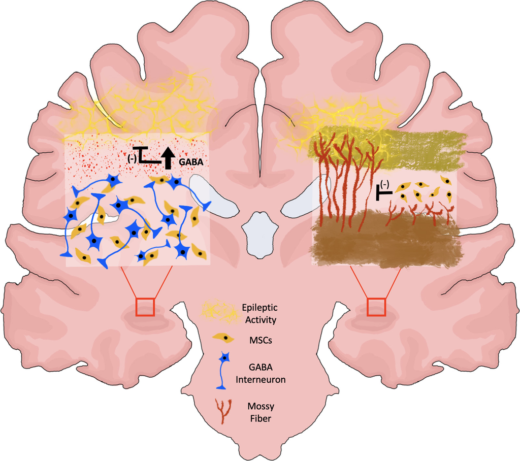

**|** **1615**

RAMOS- FRESNEDO et al.

Hippocampal sclerosis is characterized by a reduction

in the number of GABAergic interneurons.<sup>3– 5</sup> Normally,

these neurons have an inhibitory function and halt the

propagation of epileptiform activity throughout the hip-

pocampus that would otherwise potentially provoke a

seizure.<sup>3– 5</sup> Animal models in rodents have shown that

MSCs have the potential to differentiate into GABAergic

interneurons, and a statistically significant increase in

their number within the hippocampus.<sup>21– 23</sup> A study per-

formed by Long et al. (2013)<sup>30</sup> successfully explored ge-

netically modifying MSCs to silence the Hes1 gene, whose

function is to inhibit GABAergic differentiation, thereby

inducing MSC differentiation into GABAergic interneu-

rons. Histological analysis of animals treated with MSCs

have also shown a statistically significant increase in hip-

pocampal volume compared to sham treatment.<sup>21,23</sup>

4.1.4 | Clinical benefits

Animal models of epilepsy treated with MSCs show a

statistically significant clinical response compared to

control animals. Several studies have found that MSCs

reduce the frequency, duration, and severity of spontane-

ous seizures.<sup>21– 23,27– 30,32</sup> Some studies have investigated

the electrophysiology of their subjects through electro-

corticography (ECoG) or electroencephalography (EEG),

showing a reduction in the frequency and the amplitude

of seizures.<sup>27,30</sup> MSCs also seem to have a positive effect

on the cognitive ability of animals, with a statistically sig-

nificant improvement in their cognitive capabilities and

returning it to a normal level.<sup>21,22</sup>

Macroscopically, damaged brain parenchyma from epilep-

tic animal models have been shown to benefit from MSCs.<sup>32</sup>

Huang et al. (2016) showed that reduced brain edema was

present on MRI in rats treated with MSCs. In addition, Park

et al. (2015) evaluated the metabolic activity of the hippocam-

pus through PET scanning and demonstrated increased glu-

cose metabolism in animals treated with MSCs.<sup>31</sup>

**4.2** | **Clinical studies of**

**epilepsy and MSCs**

4.2.1 | Study design

Because novel therapeutic studies involving treatment

with MSCs for epilepsy are scarce and in the early stages

of development,<sup>34– 37</sup> our literature search yielded only

four phase 1 clinical studies,<sup>34– 37</sup> one as a case report<sup>34</sup>;

all of the reports had the primary objective of feasibil-

ity and safety with a secondary objective to evaluate

efficacy.<sup>34– 37</sup> In addition, all four studies included a

follow- up period of at least 1 year to provide support for

their objective to measure efficacy.<sup>34– 37</sup> The two largest

studies were performed by the same group with a simi-

lar therapeutic regimen, although without overlapping

patient populations.<sup>35,36</sup>

4.2.2 | Safety and efficacy of MSCs

for epilepsy

The first study by Hlebokazov et al. (2017)<sup>35</sup> was a ran-

domized, open label, phase 1 study involving a total of

22 patients with DRE: 12 received standard of care with

ASMs serving as controls and 10 received treatment with

MSCs. Patients received two injections within the same

day, one IV and one IT at the level of the lumbar spine.

For their primary end point, they reported no severe

adverse events (AEs) associated with MSC treatment.<sup>35</sup>

However, 1 of 10 of their patients reported a mild head-

ache after the intrathecal injection that resolved spon-

taneously after 2 days. Their secondary analysis seemed

to show a statistically significant decrease in number of

spontaneous seizures, decreased seizure severity scores,

and decreased anxiety levels when compared to the con-

trol group.

Following up on their pilot study, Hlebokazov et al.

(2021)<sup>36</sup> performed a larger randomized, open label, phase

1 study involving a total of 67 patients with DRE: 33 re-

ceived standard of care with ASMs, serving as controls,

and 34 received treatment with MSCs following the

same treatment protocol. However, they sought to in-

vestigate the impact of repeat stem cell application by

repeating the initial treatment course after 6 months in

14 patients. In agreement with prior work, they found no

severe AEs related to treatment with MSCs.<sup>36</sup> For their

secondary end point they suggested a decreased average

seizure count with additional EEG evidence of this re-

duction.<sup>36</sup> Moreover, the patients who received a repeated

treatment course appeared to show further clinical and

EEG improvement compared to their counterparts.<sup>36</sup> In

addition, depression and anxiety levels of their patients

treated with MSCs appeared to be reduced compared to

their controls.<sup>36</sup>

A small non- randomized, open label, pilot study in

four pediatric patients by Milczarek et al. (2017) reported

no severe AEs. However, all subjects developed a transient

mild hyperthermia (38°C) immediately after MSC injec-

tion. For their secondary objective, there appeared to be

a reduced number of seizures and partially normalized

EEG paroxysmal patters in all four patients. The last study

published by Dong et al. (2018)<sup>34</sup> was a case report of a

pediatric patient with cerebral palsy who received three

treatment courses of MSCs. They reported no AEs related

**1616** **|**

RAMOS- FRESNEDO et al.

to the therapy along with EEG and clinical evidence sug-

gesting improvement in both epilepsy and neurological

function.

**4.3** | **Strengths and limitations**

This study has inherent strengths and limitations. To the

best of our knowledge, this is the first systematic review

evaluating both preclinical and clinical models of MSC

therapy for epilepsy. There is a risk of bias during the se-

lection process, although two blinded authors screened

all available manuscripts to reduce this bias. In this case,

no discrepancies in manuscript selection were found be-

tween the two authors. However, in case of any discrepan-

cies, we suggest that the two screening authors re- review

the full texts of those manuscripts to carefully select which

ones meet the selection criteria. Although we attempted

to make the search as comprehensible as possible, caution

needs to be taken as the literature search may have been

limited by the methodology. Future meta studies on this

topic should include indexed keywords, author- provided

keywords, and synonyms in addition to the main terms.

On the other hand, the inclusion of Scopus database pro-

vides a broader search because non- medical manuscripts

are also included. There is also a risk of bias due to the

nature of the included studies, as they are all in preclinical

and early stages of clinical development, there are small

sample sizes, and there is high variability between dosages

and routes of administration. Because all included studies

are in the early stages, they were not powered to explore

the efficacy of treatment. Careful interpretation needs to

be made of these results as they are prone to result in false

positives. This systematic review was not pre- registered

in PROSPERO as it was initially queried for another pur-

pose. However, we encourage all authors working on sys-

tematic reviews and meta- analyses to pre- register their

protocol to ensure high- quality scientific publications and

to avoid duplicated efforts. However, we provide a con-

temporary up- to- date review of the literature on this topic.

**5** | **CONCLUSION**

The treatment of epilepsy with MSCs in humans is sup-

ported by preliminary studies and thus far appears de-

void of major AEs. MSC administration is still in the

early stages of therapeutic development; however, avail-

able reports suggest potential improvement in the elec-

troclinical profile of patients with DRE. Although the

precise dosage and route of administration for MSC is

yet to be determined, improvement in comorbidities

such as anxiety and depression are an important aspect

to consider in future trials. The use of MSC holds prom-

ise for patients with DRE, and phase II trials appear

warranted.

**ACKNOWLEDGMENTS**

AQH was supported by the Mayo Clinic Professorship and

a Clinician Investigator award, a Florida State Department

of Health Research Grant, and the Mayo Clinic Graduate

School, as well as the National Institutes of Health (NIH)

(R43CA221490,

R01CA200399,

R01CA195503,

and

R01CA216855). EHM receives unrelated research support

from Boston Scientific Corp. and Varian Medical Systems,

Inc.

**CONFLICT OF INTEREST**

EHM serves on an advisory board and receives consulting

fees from Boston Scientific Corp. Neither of the remaining

authors have any conflict of interest to disclose.

**ORCID**

*Sanjeet S. Grewal*

https://orcid.

org/0000-0002-4307-7062

**REFERENCES**

1. Fisher RS, Acevedo C, Arzimanoglou A, Bogacz A, Cross JH,

Elger CE, et al. ILAE official report: a practical clinical defi-

nition of epilepsy. Epilepsia. 2014;55(4):475– 82. https://doi.

org/10.1111/epi.12550

2. Blumcke I, Spreafico R, Haaker G, Coras R, Kobow K, Bien CG,

et al. Histopathological findings in brain tissue obtained during

epilepsy Surgery. N Engl J Med. 2017;377(17):1648– 56. https://

doi.org/10.1056/NEJMo a1703784

3. de Lanerolle NC, Kim JH, Robbins RJ, Spencer DD.

Hippocampal interneuron loss and plasticity in human tem-

poral lobe epilepsy. Brain Res. 1989;495(2):387– 95. https://doi.

org/10.1016/0006- 8993(89)90234 - 5

4. de Lanerolle NC, Lee TS, Spencer DD. Astrocytes and epilepsy.

Neurotherapeutics. 2010;7(4):424– 38. https://doi.org/10.1016/j.

nurt.2010.08.002

5. de Lanerolle NC, Lee TS, Spencer DD. Histopathology

of

human

epilepsy.

Epilepsia.

2010;51:37.

https://doi.

org/10.1111/j.1528- 1167.2010.02823.x

6. Kwan P, Brodie MJ. Effectiveness of first antiepileptic drug.

Epilepsia. 2001;42(10):1255– 60. https://doi.org/10.1046/

j.1528- 1157.2001. 04501.x

7. Brodie MJ, Perucca E, Ryvlin P, Ben- Menachem E, Meencke HJ.

Comparison of levetiracetam and controlled- release carbamaz-

epine in newly diagnosed epilepsy. Neurology. 2007;68(6):402–

8. https://doi.org/10.1212/01.wnl.00002 52941.50833.4a

8. Bonnett LJ, Tudur Smith C, Donegan S, Marson AG. Treatment

outcome after failure of a first antiepileptic drug. Neurology.

2014;83(6):552– 60. https://doi.org/10.1212/wnl.00000 00000 000673

9. Kwan P, Arzimanoglou A, Berg AT, Brodie MJ, Allen Hauser W,

Mathern G, et al. Definition of drug resistant epilepsy: consen-

sus proposal by the ad hoc Task Force of the ILAE Commission

on Therapeutic Strategies. Epilepsia. 2010;51(6):1069– 77.

https://doi.org/10.1111/j.1528- 1167.2009.02397.x

**|** **1617**

RAMOS- FRESNEDO et al.

10. Sperling MR, O'Connor MJ, Saykin AJ, Plummer C. Temporal

lobectomy for refractory epilepsy. JAMA. 1996;276(6):470– 5.

11. Engel J Jr, Wiebe S, French J, eSperling M, Williamson P,

Spencer D, et al. Practice parameter: temporal lobe and local-

ized neocortical resections for epilepsy: report of the Quality

Standards Subcommittee of the American Academy of

Neurology, in association with the American Epilepsy Society

and the American Association of Neurological Surgeons.

Neurology.

2003;60(4):538– 47.

https://doi.org/10.1212/01.

wnl.00000 55086.35806.2d

12. Fričová D, Korchak JA, Zubair AC. Challenges and translational

considerations of mesenchymal stem/stromal cell therapy for

Parkinson's disease. NPJ Regen Med. 2020;5(1):20. doi:https://

doi.org/10.1038/s4153 6- 020- 00106 - y

13. Huang P, Gebhart N, Richelson E, Brott TG, Meschia

JF, Zubair AC. Mechanism of mesenchymal stem cell-

induced

neuron

recovery

and

anti- inflammation.

Cytotherapy. 2014;16(10):1336– 44. https://doi.org/10.1016/j.

jcyt.2014.05.007

14. Lightner AL, Wang Z, Zubair AC, Dozois EJ. A systematic re-

view and meta- analysis of mesenchymal stem cell injections

for the treatment of perianal Crohn's disease: progress made

and future directions. Dis Colon Rectum. 2018;61(5):629– 40.

https://doi.org/10.1097/dcr.00000 00000 001093

15. Qu W, Wang Z, Hare JM, Bu G, Mallea JM, Pascual JM, et al.

Cell- based therapy to reduce mortality from COVID- 19: sys-

tematic review and meta- analysis of human studies on

acute respiratory distress syndrome. Stem Cells Transl Med.

2020;9(9):1007– 22. https://doi.org/10.1002/sctm.20- 0146

16. Suh A, Pham A, Cress MJ, Pincelli T, TerKonda SP, Bruce

AJ, et al. Adipose- derived cellular and cell- derived regener-

ative therapies in dermatology and aesthetic rejuvenation.

Ageing Res Rev. 2019;54:100933. https://doi.org/10.1016/j.

arr.2019.100933

17. Al- Kharboosh R, ReFaey K, Lara- Velazquez M, Grewal SS,

Imitola J, Quiñones- Hinojosa A. Inflammatory mediators in

glioma microenvironment play a dual role in gliomagenesis

and mesenchymal stem cell homing: implication for cellular

therapy. Mayo Clin Proc Innov Qual Outcomes. 2020;4(4):443–

59. https://doi.org/10.1016/j.mayoc piqo.2020.04.006

18. Feng Y, Zhu M, Dangelmajer S, Lee YM, Wijesekera O,

Castellanos CX, et al. Hypoxia- cultured human adipose-

derived mesenchymal stem cells are non- oncogenic and have

enhanced viability, motility, and tropism to brain cancer. Cell

Death Dis. 2014;5(12):e1567. doi:https://doi.org/10.1038/

cddis.2014.521

19. Li Q, Wijesekera O, Salas SJ, Wang JY, Zhu M, Aprhys C, et al.

Mesenchymal stem cells from human fat engineered to secrete

BMP4 are nononcogenic, suppress brain cancer, and prolong

survival. Clin Cancer Res. 2014;20(9):2375– 87. https://doi.

org/10.1158/1078- 0432.Ccr- 13- 1415

20. Momin EN, Mohyeldin A, Zaidi HA, Vela G, Quiñones-

Hinojosa A. Mesenchymal stem cells: new approaches for

the treatment of neurological diseases. Curr Stem Cell Res

Ther. 2010;5(4):326– 44. https://doi.org/10.2174/15748 88107

93351631

21. Fukumura S, Sasaki M, Kataoka- Sasaki Y, Oka S, Nakazaki M,

Nagahama H, et al. Intravenous infusion of mesenchymal stem

cells reduces epileptogenesis in a rat model of status epilepticus.

Epilepsy Res. 2018;141:56– 63. https://doi.org/10.1016/j.eplep

syres.2018.02.008

22. Mohammed AS, Ewais MM, Tawfik MK, Essawy SS. Effects of

intravenous human umbilical cord blood mesenchymal stem

cell therapy versus gabapentin in pentylenetetrazole- induced

chronic epilepsy in rats. Pharmacology. 2014;94(1– 2):41– 50.

https://doi.org/10.1159/00036 5219

23. Huang PY, Shih YH, Tseng YJ, Ko TL, Fu YS, Lin YY. Xenograft

of human umbilical mesenchymal stem cells from Wharton's

jelly as a potential therapy for rat pilocarpine- induced epilepsy.

Brain Behav Immun. 2016;54:45– 58. https://doi.org/10.1016/j.

bbi.2015.12.021

24. Richardson WS, Wilson MC, Nishikawa J, Hayward RS. The

well- built clinical question: a key to evidence- based decisions.

ACP J Club. 1995;123(3):A12– 3.

25. Moher D, Liberati A, Tetzlaff J, Altman DG, The PG. Preferred

reporting items for systematic reviews and meta- analyses:

the PRISMA statement. PLoS Medicine. 2009;6(7):e1000097.

https://doi.org/10.1371/journ al.pmed.1000097

26. Ali I, Aertgeerts S, Le Blon D, Bertoglio D, Hoornaert C,

Ponsaerts P, et al. Intracerebral delivery of the M2 polar-

izing cytokine interleukin 13 using mesenchymal stem

cell implants in a model of temporal lobe epilepsy in mice.

Epilepsia.

2017;58(6):1063– 72.

https://doi.org/10.1111/

epi.13743

27. Kang H, Hu Q, Liu X, Liu Y, Xu F, Li X, et al. Reconstruction of

the adenosine system by bone marrow- derived mesenchymal

stem cell transplantation. Neural Regen Res. 2012;7(4):251– 5.

https://doi.org/10.3969/j.issn.1673- 5374.2012.04.002

28. Li T, Ren G, Kaplan DL, Boison D. Human mesenchymal stem

cell grafts engineered to release adenosine reduce chronic

seizures in a mouse model of CA3- selective epileptogenesis.

Epilepsy Res. 2009;84(2– 3):238– 41. https://doi.org/10.1016/j.

eplep syres.2009.01.002

29. Long Q, Li J, Luo Q, Hei Y, Wang K, Tian Y, et al. MRI tracking

of bone marrow mesenchymal stem cells labeled with ultra-

small superparamagnetic iron oxide nanoparticles in a rat

model of temporal lobe epilepsy. Neurosci Lett. 2015;606:30– 5.

https://doi.org/10.1016/j.neulet.2015.08.040

30. Long Q, Qiu B, Wang K, Yang J, Jia C, Xin W, et al. Genetically

engineered bone marrow mesenchymal stem cells improve

functional outcome in a rat model of epilepsy. Brain Res.

2013;532:1– 13. https://doi.org/10.1016/j.brain res.2013.07.020

31. Park GY, Lee EM, Seo MS, Seo YJ, Oh JS, Son WC, et al.

Preserved hippocampal glucose metabolism on 18f- FDG PET

after transplantation of human umbilical cord blood- derived

mesenchymal stem cells in chronic epileptic rats. J Korean

Med

Sci.

2015;30(9):1232– 40.

https://doi.org/10.3346/

jkms.2015.30.9.1232

32. Ren G, Li T, Lan JQ, Wilz A, Simon RP, Boison D. Lentiviral

RNAi- induced downregulation of adenosine kinase in human

mesenchymal stem cell grafts: a novel perspective for sei-

zure control. Exp Neurol. 2007;208(1):26– 37. https://doi.

org/10.1016/j.expne urol.2007.07.016

33. Salem NA, El- Shamarka M, El- Shebiney S, Khadrawy Y. New

prospects of mesenchymal stem cells for ameliorating tempo-

ral lobe epilepsy. Inflammopharmacology. 2018;26(4):963– 72.

https://doi.org/10.1007/s1078 7- 018- 0456- 2

**1618** **|**

RAMOS- FRESNEDO et al.

34. Dong H, Li G, Shang C, Yin H, Luo Y, Meng H, et al. Umbilical

cord mesenchymal stem cell (UC- MSC) transplantations for ce-

rebral palsy. Am J Transl Res. 2018;10(3):901– 6.

35. Hlebokazov F, Dakukina T, Ihnatsenko S, Kosmacheva

S, Potapnev M, Shakhbazau A, et al. Treatment of re-

fractory epilepsy patients with autologous mesenchymal

stem cells reduces seizure frequency: an open label study.

Adv Med Sci. 2017;62(2):273– 9. https://doi.org/10.1016/j.

advms.2016.12.004

36. Hlebokazov F, Dakukina T, Potapnev M, Kosmacheva S, Moroz

L, Misiuk N, et al. Clinical benefits of single vs repeated courses

of mesenchymal stem cell therapy in epilepsy patients. Clin

Neurol Neurosurg. 2021;207:106736. https://doi.org/10.1016/j.

cline uro.2021.106736

37. Milczarek O, Jarocha D, Starowicz- Filip A, Kwiatkowski

S, Badyra B, Majka M. Multiple autologous bone marrow-

derived CD271(+) mesenchymal stem cell transplanta-

tion overcomes drug- resistant epilepsy in children. Stem

Cells Transl Med. 2018;7(1):20– 33. https://doi.org/10.1002/

sctm.17- 0041

38. Racine RJ. Modification of seizure activity by electrical stimula-

tion: II. Motor seizure. Electroencephalogr Clin Neurophysiol.

1972;32(3):281– 94. https://doi.org/10.1016/0013- 4694(72)90177 - 0

39. Racine RJ. Modification of seizure activity by electrical stim-

ulation. I. After- discharge threshold. Electroencephalogr

Clin

Neurophysiol.

1972;32(3):269– 79.

https://doi.

org/10.1016/0013- 4694(72)90176 - 9

40. Represa A, Jorquera I, Le gal la Salle G, Ben- Ari Y. Epilepsy in-

duced collateral sprouting of hippocampal mossy fibers: does it

induce the development of ectopic synapses with granule cell

dendrites? Hippocampus. 1993;3(3):257– 68.

41. Sloviter RS, Zappone CA, Harvey BD, Frotscher M. Kainic acid-

induced recurrent mossy fiber innervation of dentate gyrus

inhibitory interneurons: possible anatomical substrate of gran-

ule cell hyperinhibition in chronically epileptic rats. J Comp

Neurol. 2006;494(6):944– 60.

42. Sutula T, He X- X, Cavazos J, Scott G. Synaptic reorganization

in the hippocampus induced by abnormal functional activity.

Science. 1988;239(4844):1147– 50.

43. Cavarsan CF, Malheiros J, Hamani C, Najm I, Covolan L.

Is mossy fiber sprouting a potential therapeutic target for

epilepsy? Review. Front Neurol. 2018;9:1023. https://doi.

org/10.3389/fneur.2018.01023

44. Amaral DG, Scharfman HE, Lavenex P. The dentate gyrus:

fundamental neuroanatomical organization (dentate gyrus

for dummies). In: Scharfman HE, editor. Progress in brain re-

search. Elsevier; 2007. p. 3– 790.

**How to cite this article:** Ramos- Fresnedo A,

Perez- Vega C, Domingo RA, Lee SJ, Perkerson RB,

Zubair AC, et al. Mesenchymal stem cell therapy for

focal epilepsy: A systematic review of preclinical

models and clinical studies. Epilepsia. 2022;63:1607–

1618. https://doi.org/10.1111/epi.17266